# AID Clase 9

Cecilia Oliva

22 de junio de 2019

# Comparación de Medias (caso univariado)

```r
#recordar instalar los paquetes si no están instalados aún
#library(ggplot2)
#library(stats)
#library(reshape2)
#library(car)
#library(nortest)
#library(MASS)
#library(pgirmess)
```

### ANOVA de 1 factor utilizando transformaciones de Box-Cox

Con la intención de evaluar la eficacia de un medicamento en el nivel de alerta de unos pacientes, tres dosis (a, b, c) de un determinado fármaco se administraron a 18 sujetos. Se pide analizar la eficacia del medicamento.

```r
dosis<-c(rep("a",6),rep("b",8),rep("c",4))
alerta<-c(30,38,35,41,27,24,32,26,31,29,27,35,21,25,17,21,20,19)
data<-data.frame(dosis,alerta)
head(data,8)
```

```
##   dosis alerta
## 1     a     30
## 2     a     38
## 3     a     35
## 4     a     41
## 5     a     27
## 6     a     24
## 7     b     32
## 8     b     26
```

Para analizar la eficacia del medicamento, veamos si existen diferencias entre las medias de las tres dosis. Aplicamos ANOVA.

```r
aov.data<-aov(alerta~dosis,data=data)
summary(aov.data)
```

```
##             Df Sum Sq Mean Sq F value  Pr(>F)
## dosis        2  426.2  213.12   8.789 0.00298 **
## Residuals   15  363.8   24.25
## ---
## Signif. codes:  0 '***' 0.001 '**' 0.01 '*' 0.05 '.' 0.1 ' ' 1
```

Se puede ver que existen diferencias estadísticamente significativas entre los niveles del fármaco (p=0.00298 <0.05). Para asegurar la validez de esta afirmación realizamos las siguientes pruebas diagnósticas.

La siguiente tabla muestra las medias total y por nivel de los 3 medicamentos:

```r
print(model.tables(aov.data,"means"))
```

```
## Tables of means
## Grand mean
##
## 27.66667
##
##  dosis
##        a     b     c
##     32.5 28.25 19.25
## rep  6.0  8.00  4.00
```

#### Analizamos normalidad:

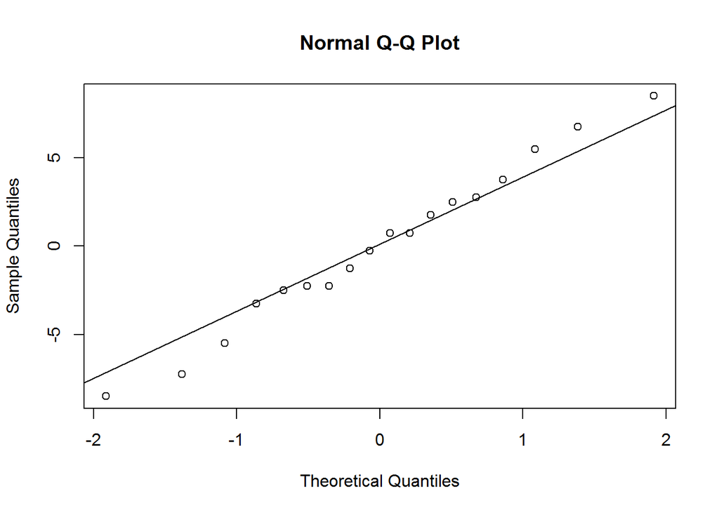

```r
qqnorm(resid(aov.data))
qqline(resid(aov.data))
```

```r
shapiro.test(residuals(aov.data))
```

```
##
##  Shapiro-Wilk normality test
##
## data:  residuals(aov.data)
## W = 0.98604, p-value = 0.991
```

```r
ad.test(residuals(aov.data))
```

```
##
##  Anderson-Darling normality test
##
## data:  residuals(aov.data)
## A = 0.11805, p-value = 0.987
```

#### Analizamos igualdad de varianzas (homoscedasticidad):

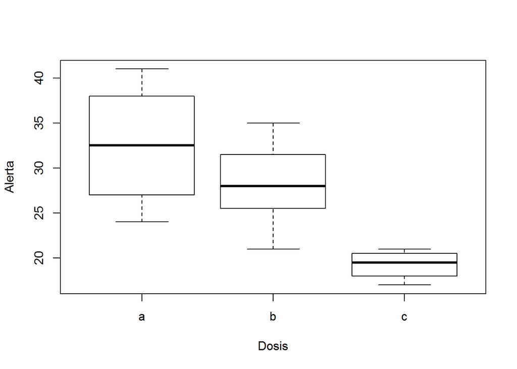

```r
boxplot(split(data$alerta,data$dosis),ylab="Alerta",xlab="Dosis")
```

Las varianzas estimadas en cada grupo son:

```r
tapply(data$alerta,data$dosis,var,na.rm=TRUE)
```

```
##         a         b         c
## 43.500000 19.642857  2.916667
```

```r
bartlett.test(alerta,dosis)
```

```
##
##  Bartlett test of homogeneity of variances
##
## data:  alerta and dosis
## Bartlett's K-squared = 4.4546, df = 2, p-value = 0.1078
```

```r
leveneTest(alerta~as.factor(dosis))
```

```
## Levene's Test for Homogeneity of Variance (center = median)
##       Df F value  Pr(>F)
## group  2  4.1667 0.03638 *
##       15
## ---
## Signif. codes:  0 '***' 0.001 '**' 0.01 '*' 0.05 '.' 0.1 ' ' 1
```

OJO: Hay que tener en cuenta el tamaño muestral, cuando el tamaño de la muestra es pequeño, incluso grandes desviaciones de la normal no se detectan, y cuando el tamaño de la muestra es grande, incluso la más mínima desviación de la normalidad logra rechazar la hipótesis nula. En este caso, al ser la muestra pequeña y el test de Bartlett sensible a las desviaciones de la normalidad, este test no detecta diferencia de varianzas (heterocedasticidad) en los niveles del factor (dosis). Por eso, es conveniente utilizar el test de Levene, el cual rechaza la homoscedasticidad, lo que indica que NO se cumple uno de los supuestos del ANOVA.

Para resolver este problema, puede ser útil alguna transformación de Box-Cox:

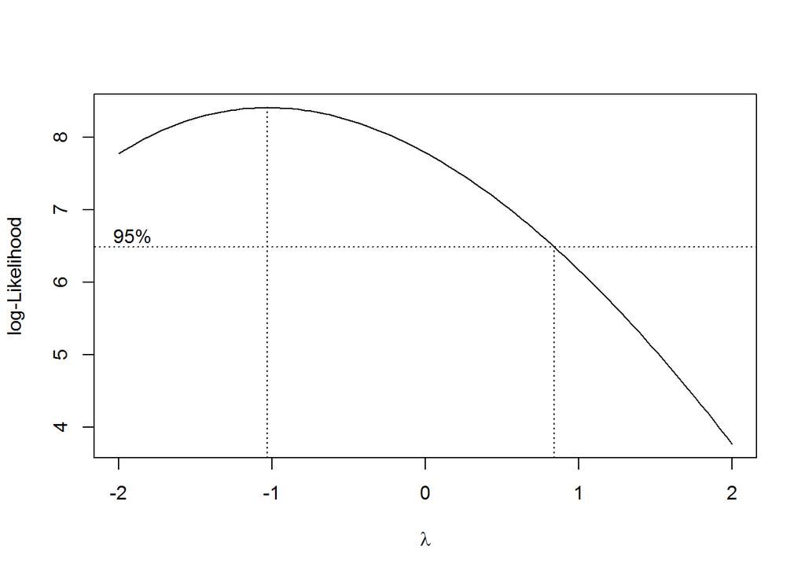

```r
#library(MASS)
boxcox(alerta~dosis,data=data,plotit=TRUE)# el máximo lambda se alcanza en -1.
```

Se repite el procedimiento para la variable transformada, y se revisa el cumplimiento de supuestos para aplicar ANOVA.

```r
aov.data2=aov(alerta^(-1)~dosis,data=data)
summary(aov.data2)
```

```
##             Df    Sum Sq   Mean Sq F value   Pr(>F)
## dosis        2 0.0010623 0.0005311   14.64 0.000298 ***
## Residuals   15 0.0005442 0.0000363
## ---
## Signif. codes:  0 '***' 0.001 '**' 0.01 '*' 0.05 '.' 0.1 ' ' 1
```

Se obtiene, como con la variable original, diferencias estadísticamente significativas entre los niveles del factor dosis.

#### Revisión de supuestos necesarios para aplicar ANOVA:

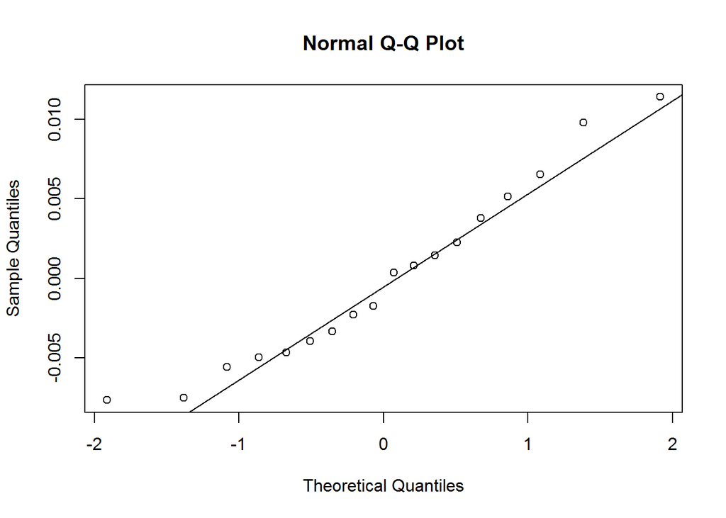

```r
qqnorm(resid(aov.data2))
qqline(resid(aov.data2))
```

```r
shapiro.test(residuals(aov.data2))
```

```
##
##  Shapiro-Wilk normality test
##
## data:  residuals(aov.data2)
## W = 0.95026, p-value = 0.4291
```

```r
ad.test(residuals(aov.data))
```

```
##
##  Anderson-Darling normality test
##
## data:  residuals(aov.data)
## A = 0.11805, p-value = 0.987
```

```r
leveneTest(alerta^(-1)~as.factor(dosis),data=data)
```

```
## Levene's Test for Homogeneity of Variance (center = median)
##       Df F value Pr(>F)
## group  2  0.4496 0.6462
##       15
```

Con la transformación de Box-Cox realizada se verifican los supuestos necesarios y por lo tanto el resultado del ANOVA aplicado es válido.

Los intervalos de confianza simultáneos para las diferencias de medias de Tukey resultan:

```r
TukeyHSD(aov.data2,conf.level=0.95)
```

```
##   Tukey multiple comparisons of means
##     95% family-wise confidence level
##
## Fit: aov(formula = alerta^(-1) ~ dosis, data = data)
##
## $dosis
##            diff          lwr        upr     p adj
## b-a 0.004324235 -0.004125103 0.01277357 0.4013805
## c-a 0.020382789  0.010283900 0.03048168 0.0002760
## c-b 0.016058555  0.006477907 0.02563920 0.0015462
```

### Test no paramétrico de Kruskal Wallis para k muestras independientes

Un estudio compara el número de huevos que pone un determinado insecto bajo 3 condiciones distintas. ¿Existen diferencias significativas dependiendo de las condiciones?

Tener en cuenta que el Test no paramétrico de Kruskal Wallis no requiere normalidad de los datos, pero sí homogeneidad de la varianza (homoscedasticidad).

```r
datos <- data.frame(condicion = c(rep("condicion1", 18), rep("condicion2", 18), rep("condicion3", 18)), n_huevos = c(1, 2, 3, 4, 5, 6, 7, 8, 9, 16, 27, 28, 29, 30, 51, 52, 53, 342, 40, 41, 42, 43, 44, 45, 46, 47, 48, 67, 88, 89, 90, 91, 92, 93, 94, 293, 19, 20, 21, 22, 23, 24, 25, 26, 27, 28, 25, 36, 37, 58, 59, 60, 71, 72))
head(datos)
```

```
##    condicion n_huevos
## 1 condicion1        1
## 2 condicion1        2
## 3 condicion1        3
## 4 condicion1        4
## 5 condicion1        5
## 6 condicion1        6
```

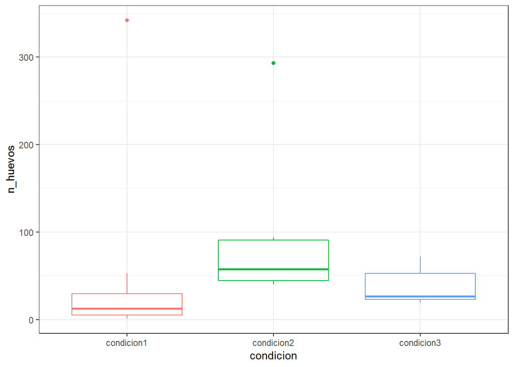

```r
ggplot(data = datos, mapping = aes(x = condicion, y = n_huevos, colour = condicion)) +
  geom_boxplot() + theme_bw() + theme(legend.position = "none")
```

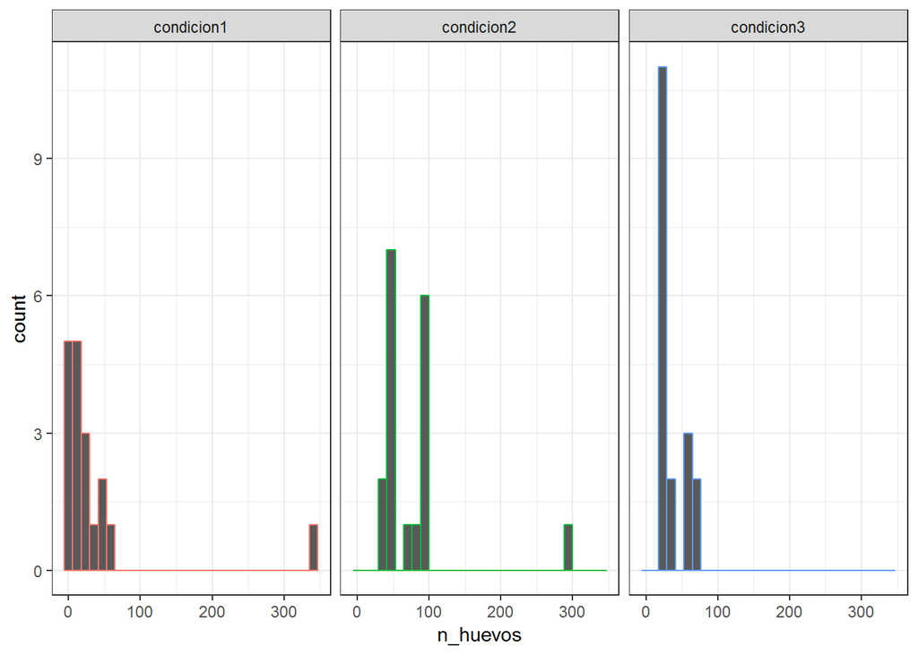

```r
ggplot(data = datos, mapping = aes(x = n_huevos, colour = condicion)) +
  geom_histogram() + theme_bw() + facet_grid(. ~ condicion) +
  theme(legend.position = "none")# + stat_bin(binwidth=30)
```

```r
leveneTest(n_huevos ~ condicion, data = datos)
```

```
## Levene's Test for Homogeneity of Variance (center = median)
##       Df F value Pr(>F)
## group  2  0.7929  0.458
##       51
```

```r
kruskal.test(n_huevos ~ condicion, data = datos)
```

```
##
##  Kruskal-Wallis rank sum test
##
## data:  n_huevos by condicion
## Kruskal-Wallis chi-squared = 19.964, df = 2, p-value = 4.623e-05
```

```r
#library(pgirmess)
kruskalmc(datos$n_huevos ~ datos$condicion)
```

```
## Multiple comparison test after Kruskal-Wallis
## p.value: 0.05
## Comparisons
##                         obs.dif critical.dif difference
## condicion1-condicion2 22.888889     12.55414       TRUE
## condicion1-condicion3  7.111111     12.55414      FALSE
## condicion2-condicion3 15.777778     12.55414       TRUE
```